# Investigate Bicoid motif contribution

Kaelan (1028-02098-001-001)

May 04, 2023

# 1. Introduction

The goal of this analysis is to study how the Bicoid motif contributes to chromatin accessibility as predicted by the trained ChromBPNet models. We will give specific attention to genomic regions that were previously characterized as depending on Bicoid for accessibility (Bicoid-dependent; Hannon et al., 2017) as compared to Biocid motifs that don’t depend on Bicoid for accessibility. We will further visualize Bicoid motif contribution at known AP patterning enhancers. These results are expected to be part of the supplemental material in Brennan et al.

# 2. Computational Setup

```r
#Standard packages
library(rtracklayer) ; library(GenomicRanges); library(magrittr) ; library(Biostrings)
library(ggplot2) ; library(reshape2); library(plyranges); library(Rsamtools); library(ggpubr)
library(dplyr); library(data.table); library(patchwork); library(readr); library(testit); library(cowplot)

#KNITR Options
setwd("/l/Zeitlinger/ZeitlingerLab/Manuscripts/Zelda_and_Nucleosomes/Analysis/analysis/")
options(knitr.figure_dir="figures/1a_plot_rep_corr/", java.parameters = "- Xmx6g")

#Lab sources
source("scripts/r/granges_common.r")
source("scripts/r/metapeak_common.r")
source("scripts/r/knitr_common.r")
source("scripts/r/caching.r")
source("scripts/r/metapeak_functions.r")

#Specific sources
library(ggseqlogo)
library(BSgenome.Dmelanogaster.UCSC.dm6)
library(rhdf5)
source("scripts/r/motif_functions.r")

#Pre-existing variables
library(GenomicFeatures)
library(TxDb.Dmelanogaster.UCSC.dm6.ensGene)
library(seqinr)
bsgenome = BSgenome.Dmelanogaster.UCSC.dm6
txdb<-TxDb.Dmelanogaster.UCSC.dm6.ensGene
```

# 3. Load relevant data

```r
# Bcd motifs

bcd_motifs.gr<-'/l/Zeitlinger/ZeitlingerLab/Manuscripts/Zelda_and_Nucleosomes/Analysis/analysis/tsv/mapped_motifs/atac_overlapping_instances_curated_w_metadata_1based.tsv.gz' %>%
  readr::read_tsv(.) %>%
  makeGRangesFromDataFrame(keep.extra.columns = T, starts.in.df.are.0based = F) %>%
  plyranges::filter(pattern_name == "Bcd")

# Bcd binding

bcd.bw.list<-list(pos = '/l/Zeitlinger/ZeitlingerLab/Manuscripts/Zelda_and_Nucleosomes/Analysis/data/bw/dm6/nexus/combined/orer_bcd_mbt_nexus_combined_normalized_positive.bw',
                  neg = '/l/Zeitlinger/ZeitlingerLab/Manuscripts/Zelda_and_Nucleosomes/Analysis/data/bw/dm6/nexus/combined/orer_bcd_mbt_nexus_combined_normalized_negative.bw')

# Hannon et al., 2017 Bcd-dependent regions

hannon_regions_bcd_dep.gr<-readRDS('/l/Zeitlinger/ZeitlingerLab/Manuscripts/Zelda_and_Nucleosomes/Analysis/data/published/hannon/bcd_dependent_regions_hannon2017_dm6.rds')

# Cusanovich 2018 enhancers: known active enhancers from blastoderm embryos compiled by the Furlong lab

cus_enhancers.gr <- rtracklayer::import('/l/Zeitlinger/ZeitlingerLab/Manuscripts/Zelda_and_Nucleosomes/Analysis/data/published/enhancers/cusanovich/cusanovich_dm6_enhancers.bed')
```

# 4. Do Bcd-dependent motifs overlap more with active enhancers than Bcd-independent

## 4.1. Filter Hannon regions for overlapping a Bcd motif

```r
# Determine which Bcd motifs overlap with the "Bcd-dependent for accessibility regions" from Hannon et al., 2017

bcd_motifs.gr$overlaps_w_hannon<-overlapsAny(bcd_motifs.gr, hannon_regions_bcd_dep.gr, ignore.strand = T)
```

## 4.2. Do Bcd-dependent motifs overlap more with active enhancers than motifs that don’t depend on Bcd for accessibility?

```r
bcd_motifs.gr$overlaps_w_cusanovich<-overlapsAny(bcd_motifs.gr, cus_enhancers.gr, ignore.strand = T)

bcd_motifs_slim.gr <- bcd_motifs.gr[,62:63]

bcd_motifs_slim.gr %>%
  as.data.frame %>%
  dplyr::group_by(overlaps_w_hannon, overlaps_w_cusanovich) %>%
  dplyr::summarize(count = dplyr::n())
```

```
## # A tibble: 4 × 3
## # Groups:   overlaps_w_hannon [2]
##   overlaps_w_hannon overlaps_w_cusanovich count
##   <lgl>             <lgl>                 <int>
## 1 FALSE             FALSE                  5110
## 2 FALSE             TRUE                    533
## 3 TRUE              FALSE                    94
## 4 TRUE              TRUE                     68
```

```r
# Create dataframe for Chi-square test

bcd.df <- data.frame(non_active  = c(5110, 94),
                  active = c(533, 68)
                  )
rownames(bcd.df) <- c("bcd_independent", "bcd_dependent")

# Perform Chi-square test: https://www.r-bloggers.com/2020/01/chi-square-test-of-independence-in-r-3/
chisq.test(bcd.df)
```

```
##
##  Pearson's Chi-squared test with Yates' continuity correction
##
## data:  bcd.df
## X-squared = 176.06, df = 1, p-value < 2.2e-16
```

```r
## double-check with Fishers exact test

fisher.test(bcd.df)
```

```
##
##  Fisher's Exact Test for Count Data
##
## data:  bcd.df
## p-value < 2.2e-16
## alternative hypothesis: true odds ratio is not equal to 1
## 95 percent confidence interval:
##  4.931557 9.701712
## sample estimates:
## odds ratio
##   6.930497
```

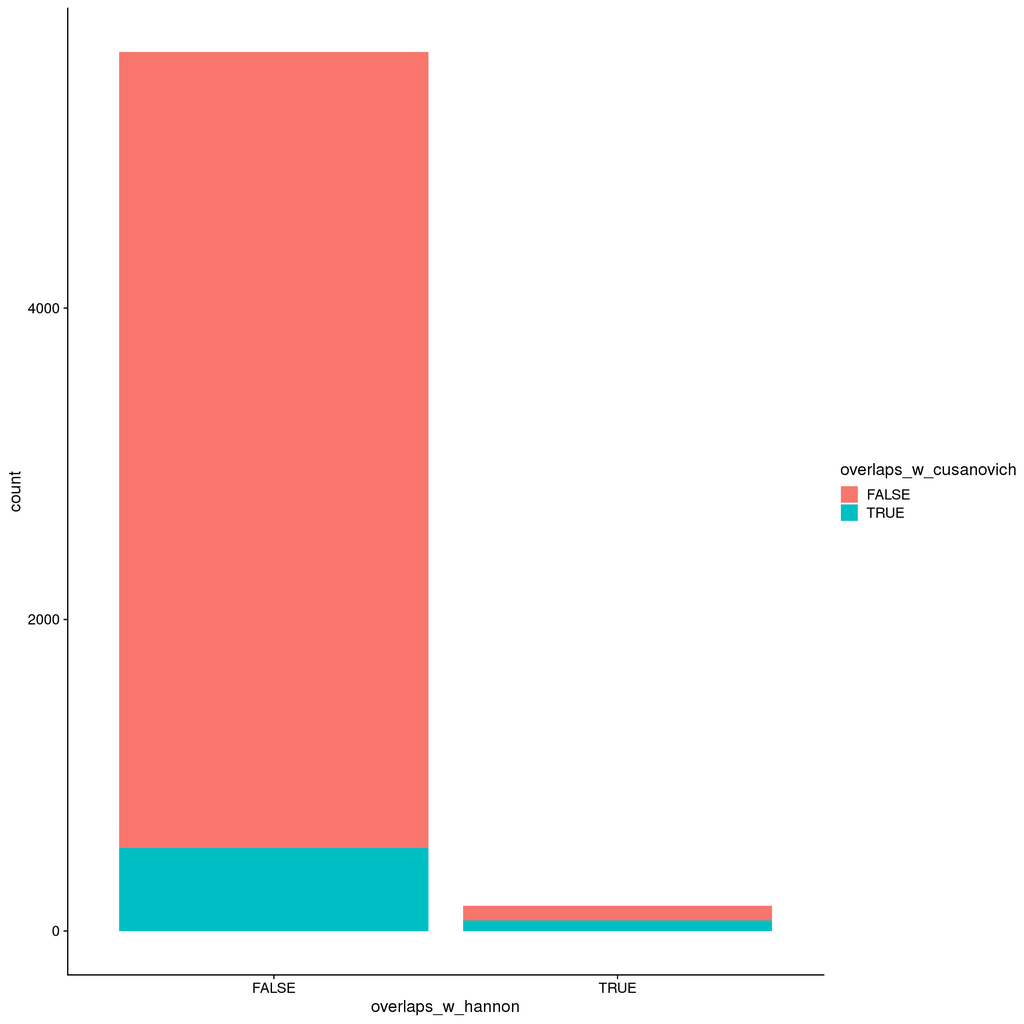

```r
# plot

overlap_bar.plot <- ggplot(as.data.frame(bcd_motifs_slim.gr), aes(x=overlaps_w_hannon, fill = overlaps_w_cusanovich)) +
  geom_bar() +
  theme_cowplot()
overlap_bar.plot
```

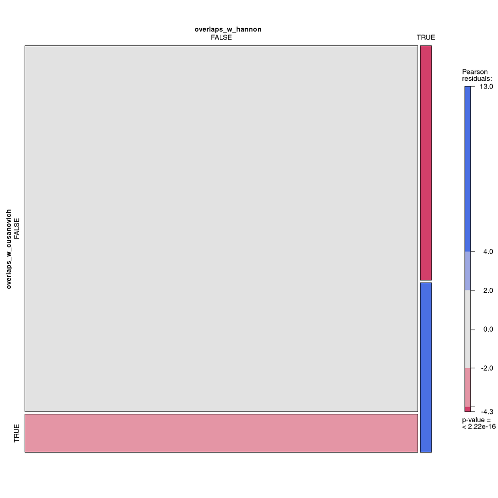

```r
# Plot mosaic plot

library(vcd)
mosaic(~ overlaps_w_hannon + overlaps_w_cusanovich,
       direction = c("v", "h"),
       data = as.data.frame(bcd_motifs_slim.gr),
       shade = TRUE)
```

# 5. Examine active enhacner histone markers and Bcd binding around Bcd motifs

## 5.1. Calculate H3K27ac, H3K4me1, and Bcd binding around Bcd motifs

```r
h3k27ac.bw <- '/l/Zeitlinger/ZeitlingerLab/Manuscripts/Zelda_and_Nucleosomes/Analysis/data/bw/dm6/seq/combined/orer_h3k27ac_mbt_seq_combined.bw'
h3k4me1.bw <-'/l/Zeitlinger/ZeitlingerLab/Manuscripts/Zelda_and_Nucleosomes/Analysis/data/bw/dm6/seq/combined/orer_h3k4me1_mbt_seq_combined.bw'

bcd_motifs.gr$h3k27ac <- regionSums(bcd_motifs.gr %>% resize(500, 'center'), h3k27ac.bw)
bcd_motifs.gr$h3k4me1 <- regionSums(bcd_motifs.gr %>% resize(500, 'center'), h3k4me1.bw)
bcd_motifs.gr$bcd_binding <-regionSums(bcd_motifs.gr %>% resize(100, 'center'), bcd.bw.list$pos) + abs(regionSums(bcd_motifs.gr %>% resize(100, 'center'), bcd.bw.list$neg))
```

## 5.2. Plot histone modifications

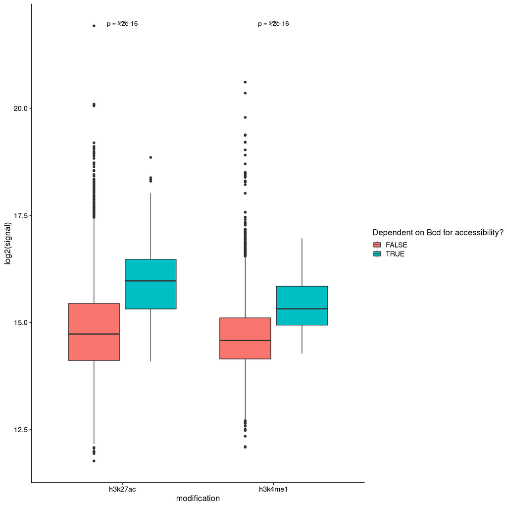

```r
bcd_motifs.df <- as.data.frame(bcd_motifs.gr)
bcd.table <- bcd_motifs.df %>%
  as.data.table %>%
  melt.data.table(id.vars = c('overlaps_w_hannon'), measure.vars = c("h3k27ac", "h3k4me1"), variable.name = 'modification', value.name = 'signal')


histones.plot <- ggplot(data = bcd.table, aes(x=modification, y=log2(signal), fill=overlaps_w_hannon)) +
  geom_boxplot() +
  stat_compare_means(aes(group = overlaps_w_hannon), method = "wilcox.test", label = "p.format", paired = FALSE) +
  stat_compare_means(aes(group = overlaps_w_hannon), method = "wilcox.test", label = "p.signif", paired = FALSE) +
  theme_cowplot() +
  guides(fill=guide_legend(title="Dependent on Bcd for accessibility?"))
histones.plot
```

```r
ggsave("histones_at_hannon_motifs.pdf", plot = histones.plot, path = "figures/3a_bcd_contrib_summarize/", width = 14, height = 10)
ggsave("histones_at_hannon_motifs.png", plot = histones.plot, path = "figures/3a_bcd_contrib_summarize/", width = 14, height = 10)
```

## 5.3. Plot Bcd binding

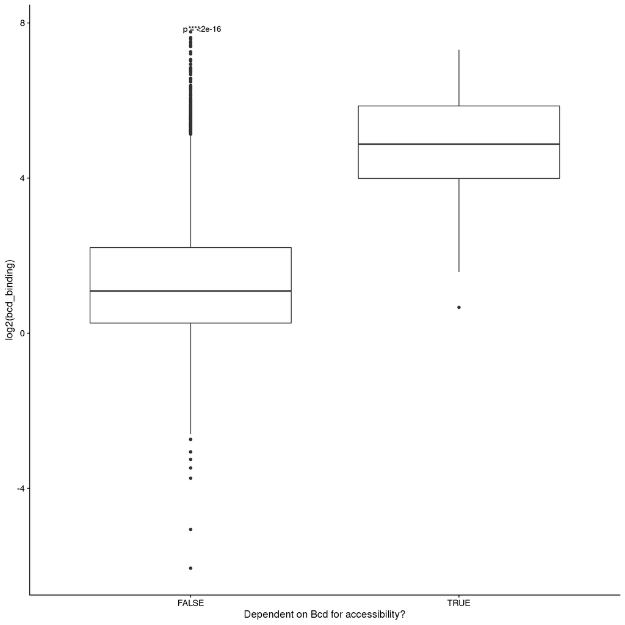

```r
binding.plot <-ggplot(as.data.frame(bcd_motifs.gr), aes(x=overlaps_w_hannon, y=log2(bcd_binding))) +
  geom_boxplot() +
  xlab("Dependent on Bcd for accessibility?") +
  stat_compare_means(method = "wilcox.test", label = "p.signif", paired = FALSE) +
  stat_compare_means(method = "wilcox.test", label = "p.format", paired = FALSE) +
  theme_cowplot()
binding.plot
```

```r
ggsave("bcd_binding_at_hannon_motifs.pdf", plot = binding.plot, path = "figures/3a_bcd_contrib_summarize/", width = 14, height = 10)
ggsave("bcd_binding_at_hannon_motifs.png", plot = binding.plot, path = "figures/3a_bcd_contrib_summarize/", width = 14, height = 10)
```

# 6. Plot Bcd at known enhancers

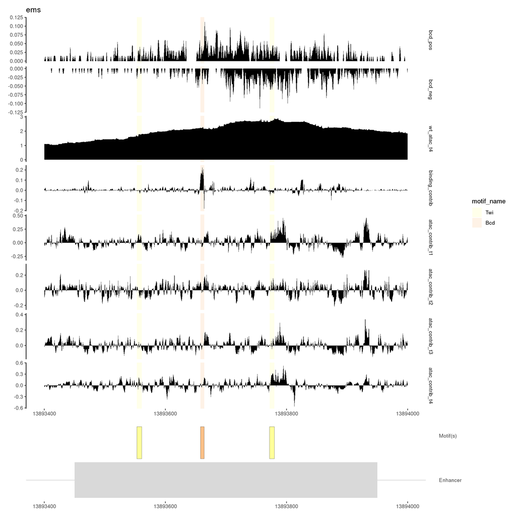

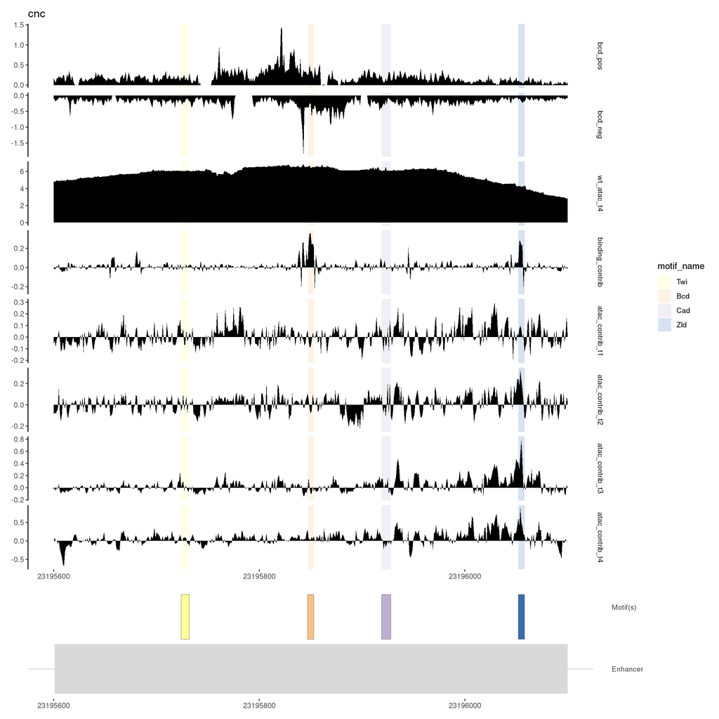

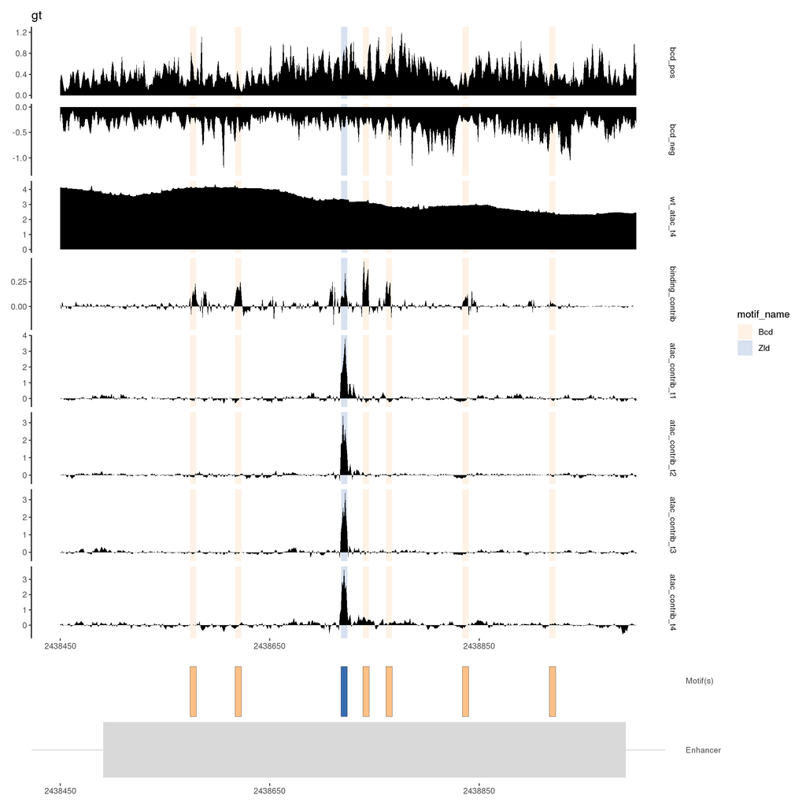

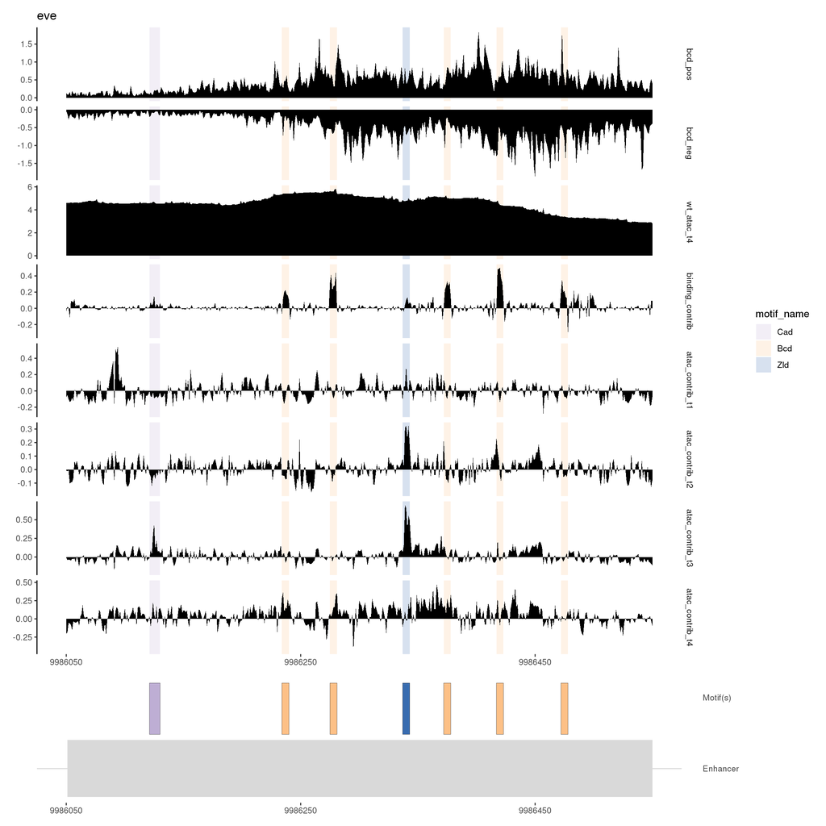

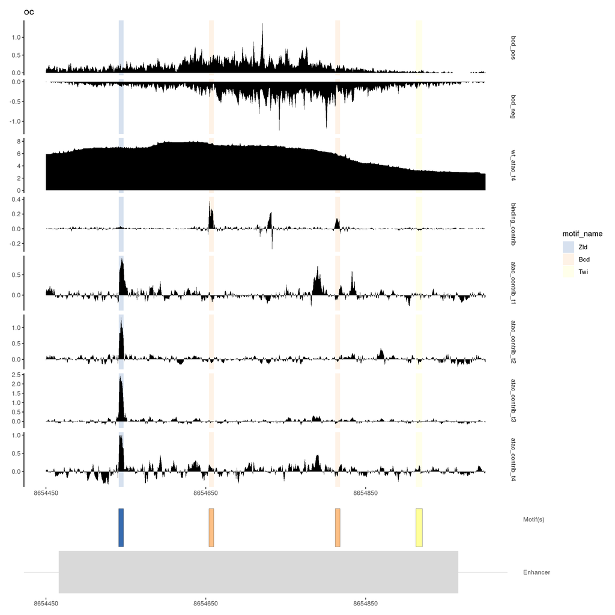

```r
# Define enhancers

enhancers.gr<-c(
  GRanges('chr3R', IRanges(start = 13893450, end = 13893950), strand = '*', name = 'ems'),
  GRanges('chr3R', IRanges(start = 23195601, end = 23196100), strand = '*', name = 'cnc'),
  GRanges('chrX', IRanges(start = 2438491, end = 2438990), strand = '*', name = 'gt'),
  GRanges('chr2R', IRanges(start = 9986051, end = 9986550), strand = '*', name = 'eve'),
  GRanges('chrX', IRanges(start = 8654466, end = 8654966), strand = '*', name = 'oc'))

# Make bw coverage list with all strains

bw.list<-list(`bcd_pos` = '/l/Zeitlinger/ZeitlingerLab/Manuscripts/Zelda_and_Nucleosomes/Analysis/data/bw/dm6/nexus/combined/orer_bcd_mbt_nexus_combined_normalized_positive.bw',
              `bcd_neg` = '/l/Zeitlinger/ZeitlingerLab/Manuscripts/Zelda_and_Nucleosomes/Analysis/data/bw/dm6/nexus/combined/orer_bcd_mbt_nexus_combined_normalized_negative.bw',
              `wt_atac_t4` = '/l/Zeitlinger/ZeitlingerLab/Manuscripts/Zelda_and_Nucleosomes/Analysis/data/bw/dm6/atac/combined/orer_25to3_atac_combined_normalized.bw',
              `binding_contrib` = '/l/Zeitlinger/ZeitlingerLab/Manuscripts/Zelda_and_Nucleosomes/Analysis/analysis/bpnet/preds/fold1/bw/Bcd.contrib.counts.bw',
              `atac_contrib_t1` = '/l/Zeitlinger/ZeitlingerLab/Manuscripts/Zelda_and_Nucleosomes/Analysis/analysis/chrombpnet/preds/preds_fold1_1to15.counts_scores_norm_99.95.bw',
              `atac_contrib_t2` = '/l/Zeitlinger/ZeitlingerLab/Manuscripts/Zelda_and_Nucleosomes/Analysis/analysis/chrombpnet/preds/preds_fold1_15to2.counts_scores_norm_99.95.bw',
              `atac_contrib_t3` = '/l/Zeitlinger/ZeitlingerLab/Manuscripts/Zelda_and_Nucleosomes/Analysis/analysis/chrombpnet/preds/preds_fold1_2to25.counts_scores_norm_99.95.bw',
              `atac_contrib_t4` = '/l/Zeitlinger/ZeitlingerLab/Manuscripts/Zelda_and_Nucleosomes/Analysis/analysis/chrombpnet/preds/preds_fold1_25to3.counts_scores_norm_99.95.bw')

# Process motifs

motifs.gr<-readr::read_tsv('/l/Zeitlinger/ZeitlingerLab/Manuscripts/Zelda_and_Nucleosomes/Analysis/analysis/tsv/mapped_motifs/all_instances_curated_1based.tsv.gz') %>%
  makeGRangesFromDataFrame(keep.extra.columns = T, starts.in.df.are.0based = F) %>%
  plyranges::mutate(motif = pattern_name,
                    name = pattern_name) %>%
  GenomicRanges::sort(ignore.strand = T)

#Specific variables
library(RColorBrewer)
n_motifs<-motifs.gr$name %>% unique %>% length
colors <- colorRampPalette(brewer.pal(n_motifs, "Accent"))(n_motifs)
# getPalette(colourCount)
# getPalette = colorRampPalette(brewer.pal(n_motifs, "Set1"))
#
# many_colors <- grDevices::colors()[grep('gr(a|e)y|white', grDevices::colors(), invert = T)]
# many_colors <- many_colors[20:(length(many_colors)-20)]
# step<-floor(length(many_colors) / n_motifs)
# colors <- many_colors[seq(1, n_motifs*step, step)]
names(colors)<-motifs.gr$name %>% unique
motif.colors.list<-as.list(colors)

# Function

plot_coverage_and_enhancer<-function(enhancer.gr, motifs.gr, bw.list, motif.colors.list, title, region_width = 1000,
                                     cores = 6, scales = 'fixed', rounding_margin = 50, label_margin = 200){

  #Assertion requirements to make the function run correctly.
  testit::assert("Input enhancer GRanges needs to contain only 1 region.", length(enhancer.gr)==1)
  testit::assert("Motifs need to be a GRanges object", is(motifs.gr, "GRanges"))
  testit::assert("Enhancers need to be a GRanges object", is(enhancer.gr, "GRanges"))
  testit::assert("Region width should be larger than enhancer width.", width(enhancer.gr)<=region_width)
  testit::assert("Bigwig object needs to be a list of samples. If samples are ChIP-nexus/double-stranded samples, they need to be in a nested list.",
                 is(bw.list, "list") & all(!(names(bw.list) %in% c("pos", "neg"))))
  testit::assert("Motif object needs a column titled pattern_name, motif_name, or name to distinguish motifs apart.",
                 any(grepl("pattern_name|name|motif_name", colnames(motifs.gr@elementMetadata))))

  #Find overlaps between motif set and enhancer
  motifs_in_enhancer.gr<-subsetByOverlaps(motifs.gr, resize(enhancer.gr, region_width, "center"), ignore.strand = T)
  if("pattern_name" %in% colnames(motifs_in_enhancer.gr@elementMetadata)){
    motifs_in_enhancer.gr$motif_name<-motifs_in_enhancer.gr$pattern_name
  }
  if("name" %in% colnames(motifs_in_enhancer.gr@elementMetadata)){
    motifs_in_enhancer.gr$motif_name<-motifs_in_enhancer.gr$name
  }

  #Extract colors for enhancer
  fills_in_order<-lapply(motifs_in_enhancer.gr$motif_name, function(x) motif.colors.list[[x]]) %>% unlist %>% unique %>% as.character
  motifs_in_order<-motifs_in_enhancer.gr$motif_name %>% unique %>% as.character
  motifs_in_enhancer.df<-motifs_in_enhancer.gr %>% as.data.frame
  motifs_in_enhancer.df$motif_name<-factor(motifs_in_enhancer.df$motif_name, levels = motifs_in_order)

  #Convert enhancer coordinates to df
  enhancer.df<-enhancer.gr %>% as.data.frame

  #Get half of the enhancer
  enh_half<-floor(width(enhancer.gr)/2)
  lower_bounds<-plyr::round_any(enhancer.df$start - (region_width/2 - enh_half), rounding_margin, f = floor)
  upper_bounds<-plyr::round_any(enhancer.df$end + (region_width/2 - enh_half), rounding_margin, f = ceiling)

  enhancer.plot<-ggplot()+
    geom_hline(yintercept = .5, color = "gray 85")+
    geom_rect(data = enhancer.df, aes(xmin = start, xmax = end, ymin = 0, ymax = 1), fill = "gray 85")+
    geom_text(data = enhancer.df, aes(x = ((start - end)/2 + start), y = .5, label = paste0(seqnames, ":", start, "-", end)),
              color = "black")
  if(nrow(motifs_in_enhancer.df)>0){
    enhancer.plot<-enhancer.plot + geom_rect(data = motifs_in_enhancer.df,
                                             aes(xmin = start, xmax = end, ymin = 1.1, ymax = 2, fill = motif_name), color = 'black', size = .1)
  }
  enhancer.plot<-enhancer.plot+
    scale_fill_manual(values = fills_in_order)+
    scale_x_continuous(breaks = seq(plyr::round_any(enhancer.df$start - (region_width/2 - enh_half), rounding_margin, f = floor),
                                    plyr::round_any(enhancer.df$end + (region_width/2 - enh_half), rounding_margin, f = ceiling), label_margin),
                       limits = c(lower_bounds,upper_bounds))+
    scale_y_continuous(breaks = c(.5, 1.75), labels = c("Enhancer", "Motif(s)"), position = "right")+
    theme_classic()+
    theme(axis.title = element_blank(), axis.line = element_blank(), axis.ticks.y = element_blank(),
          legend.position = "none")

  # Get coverage across bigwig list
  coverage.df<-parallel::mclapply(names(bw.list), function(x){
    if(length(bw.list[[x]])==1){
      df<-standard_metapeak(resize(enhancer.gr, 1, "center"), bw.list[[x]], upstream = floor(region_width/2) + rounding_margin, downstream = floor(region_width/2)+300) %>%
        dplyr::rename(window_distance = tss_distance) %>%
        dplyr::mutate(position = window_distance + start(resize(enhancer.gr, 1, "center")), sample_name = x)
    }
    if(length(bw.list[[x]])==2){
      df<-exo_metapeak(resize(enhancer.gr, 1, "center"), bw.list[[x]], upstream = region_width/2 + rounding_margin, downstream = region_width/2+rounding_margin) %>%
        dplyr::rename(window_distance = tss_distance) %>%
        dplyr::mutate(position = window_distance + start(enhancer.gr), sample_name = x)
    }
    return(df)
  }, mc.cores = cores) %>% rbindlist() %>%
    dplyr::filter(position >= lower_bounds, position <= upper_bounds) %>%
    dplyr::mutate(sample_name = factor(sample_name, levels = names(bw.list)))

  #Check for strand if there are no 2-channeled samples.
  if(!("strand" %in% colnames(coverage.df))){
    coverage.df$strand<-NA
  }

  #Plot the enhancer coverage.
  coverage.plot<-ggplot(coverage.df)
  if(nrow(motifs_in_enhancer.df)>0){
    coverage.plot<-coverage.plot + geom_rect(data = motifs_in_enhancer.df, aes(xmin = start, xmax = end, ymin = -Inf, ymax = Inf, fill = motif_name), alpha = .2)
  }
  coverage.plot<-coverage.plot +
    geom_area(aes(x = position, y = reads, group = strand), fill = "black")+
    geom_text(aes(x = Inf, y = Inf, label = sample_name), hjust = -.01)+
    scale_fill_manual(values = fills_in_order)+
    scale_x_continuous(breaks = seq(plyr::round_any(enhancer.df$start - (region_width/2 - enh_half), rounding_margin, f = floor),
                                    plyr::round_any(enhancer.df$end + (region_width/2 - enh_half), rounding_margin, f = ceiling), label_margin),
                       limits = c(lower_bounds,upper_bounds))+
    facet_grid(sample_name ~ ., scales = scales)+
    ggtitle(title)+
    theme_classic()+
    theme(axis.title = element_blank(), axis.line.x = element_blank(), strip.background = element_blank())

  g<-coverage.plot + enhancer.plot + plot_layout(ncol = 1, heights = c(5, 1))
  return(g)
}

# Plot regions

parallel::mclapply(1:length(enhancers.gr), function(x){
  enhancer.gr = enhancers.gr[x]
  g<-plot_coverage_and_enhancer(enhancer.gr = enhancer.gr, motifs.gr = motifs.gr, bw.list = bw.list,
                                motif.colors.list = motif.colors.list, title = enhancer.gr$name,
                                region_width = width(enhancer.gr), cores = 6, scales = 'free')
  ggsave(paste0("figures/3a_bcd_contrib_summarize/", enhancer.gr$name,"_single_example.pdf"), g, height = 15, width = 20)
  ggsave(paste0("figures/3a_bcd_contrib_summarize/", enhancer.gr$name,"_single_example.png"), g, height = 15, width = 20)
  return(g)
}, mc.cores = 4)
```

# 7. Do Bicoid-dependent motifs have higher ChromBPNet ATAC-seq contribution?

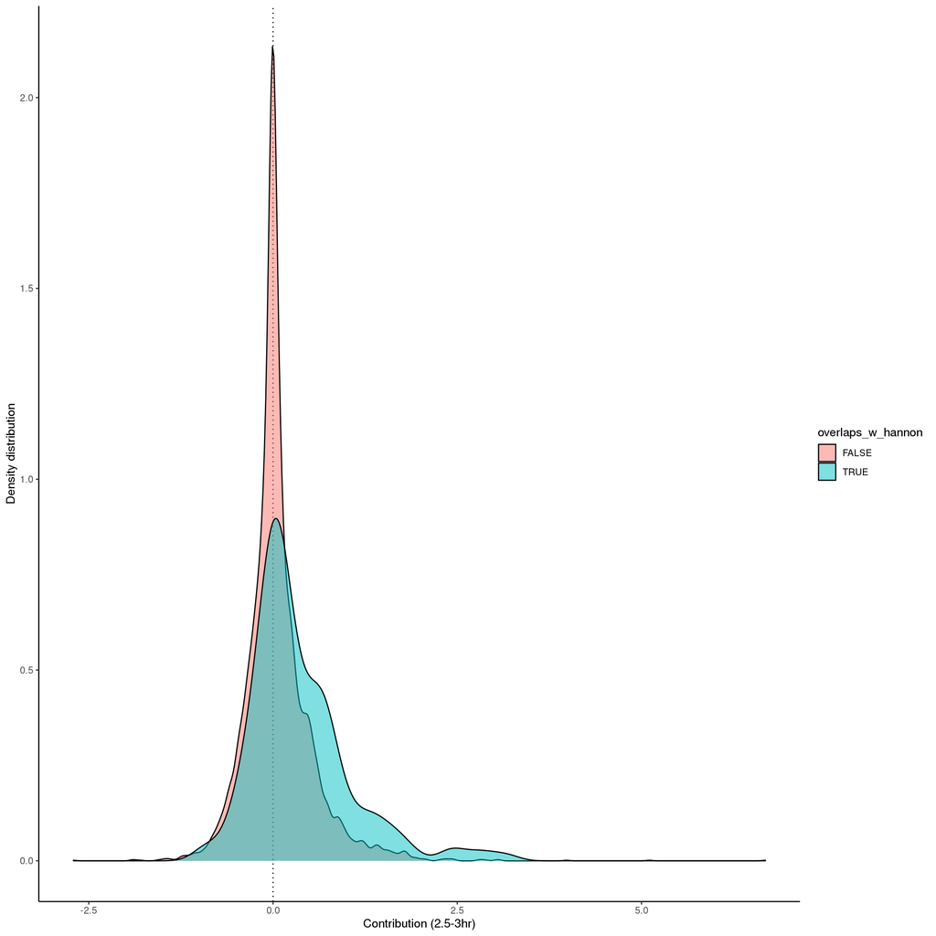

```r
# format

tasks<-c('Bcd','Dl','Zld')

motifs.gr<-'/l/Zeitlinger/ZeitlingerLab/Manuscripts/Zelda_and_Nucleosomes/Analysis/analysis/tsv/mapped_motifs/atac_overlapping_instances_curated_w_metadata_1based.tsv.gz' %>%
  readr::read_tsv(.) %>%
  makeGRangesFromDataFrame(keep.extra.columns = T, starts.in.df.are.0based = F)

motifs.gr.list<-lapply(tasks, function(x){
  motifs.gr %>%
  plyranges::filter(pattern_name == x)
})
names(motifs.gr.list)<-tasks

# calculate signal and overlaps

bcd.gr<-motifs.gr.list$Bcd %>%
  resize(width = 1, fix = 'center') %>%
  plyranges::arrange(desc(`25to3`)) %>%
  plyranges::mutate(bcd_signal = regionSums(resize(., width = 200, fix = 'center'), bcd.bw.list$pos) +
                      abs(regionSums(resize(., width = 200, fix = 'center'), bcd.bw.list$neg)))

bcd.gr$overlaps_w_hannon<-overlapsAny(bcd.gr, hannon_regions_bcd_dep.gr, ignore.strand = T)

# plot density distribution

bcd_density.plot<-bcd.gr %>%
  as.data.frame %>%
  ggplot(., aes(x = X25to3, fill = overlaps_w_hannon))+
  geom_vline(xintercept = 0, linetype = 'dotted')+
  geom_density(alpha = .5)+
  scale_x_continuous(name = 'Contribution (2.5-3hr)')+
  scale_y_continuous(name = 'Density distribution')+
  theme_classic()

ggsave("Bcd_density_via_Hannon.pdf", plot = binding.plot, path = "figures/3a_bcd_contrib_summarize/", width = 4, height = 10)
ggsave("Bcd_density_via_Hannon.png", plot = binding.plot, path = "figures/3a_bcd_contrib_summarize/", width = 4, height = 10)

bcd_density.plot
```

```r
# is it significant?

ks.test(x = bcd.gr %>% plyranges::filter(overlaps_w_hannon) %>% .$X25to3,
        y = bcd.gr %>% plyranges::filter(!overlaps_w_hannon) %>% .$X25to3)
```

```
##
##  Asymptotic two-sample Kolmogorov-Smirnov test
##
## data:  bcd.gr %>% plyranges::filter(overlaps_w_hannon) %>% .$X25to3 and bcd.gr %>% plyranges::filter(!overlaps_w_hannon) %>% .$X25to3
## D = 0.22624, p-value = 1.995e-07
## alternative hypothesis: two-sided
```

# 8. Conclusions

We can see that the Bcd motifs that Hannon reports depend on Bcd for accessibility are more associated with known active enhancers. Statistical testing shows that dependence on Bcd for accessibiliy is linked to enhancer activation, and we find that these Bcd-dependent motifs are more enriched in active enhancer characteristics including H3K27ac and H3K4me1.